# Isoform switching after LPS, and what UBL5 does to it

Lab meeting update — state of the project, open decisions, and what’s next

Author

Project

Published

August 23, 2026

**NoteHow to read this update**

This replaces the earlier seminar summary as the current picture. It covers the whole project: the original pipeline (scripts `00`–`07`), the layer-decoupling and hidden-layer work (`08`–`10`), and the external review round.

Three claims we previously reported are **withdrawn**. They are listed in Section 2 rather than quietly dropped, because two of them were headline results and one of them shaped a script. Everything still standing has been re-checked against the tables it came from.

**New since the last version:** the model-based 2x2 refit (Section 5.3), which was the step the whole Q2 question was blocked on, and the assayability screen on the Q1 candidates (Section 6.2).

# 1 Where the project stands

Two questions, tracked separately throughout because they have different answers and different levels of support.

Table 1: Current verdict on each claim, and what it rests on

| Question | Verdict | Resting on |
| --- | --- | --- |
| Splicing responds to LPS beyond what expression shows | **Supported** | 19.7% of switching genes are invisible to gene-level DE |
| The switches are promoter choice, not splicing | **Partly true** | 21.7% promoter-only, but 59.4% involve internal splicing |
| UBL5 loss blunts the LPS response globally | **Supported** | Expression response at ~half amplitude (slope 0.52, 8,595 genes) |
| UBL5 has a constitutive splicing defect | **Rejected** | Baseline composition identical to WT (0.0024 vs 0.0496 control) |
| The deficit is targeted at the LPS/TLR4 programme | **Rejected** | Transcriptome-wide; no network proximity above a degree-matched null |
| UBL5 acts on splicing specifically, not only via expression | **Unresolved** | Direct 2x2 interaction test: 2 genes of 13,086 — but underpowered (Section 5.3) |
| The KO degrades splicing more than expression | **Rejected** | Retention >=56% on one estimator, matching the expression figure (Section 5.3) |
| Q2 candidates are testable by qPCR | **Mostly no** | 6 of 7 need 5’ RACE or long reads |
| Q1 candidates are testable by qPCR | **Partly** | 25 of 63 isoforms designable; 5 genes have both sides (Section 6.2) |

**The one-line version.** Q1 is in good shape and has a real, defensible result. Q2 has a solid negative (no constitutive defect, not pathway-targeted) and a solid global phenotype (halved LPS response). The *splicing-specific* claim — the reason UBL5 is interesting — has now been tested directly for the first time and the interaction is nearly empty, but that test is underpowered at n = 3, so it stays **unresolved** rather than rejected (Section 5.3).

# 2 What changed since the last update

**ImportantThree retractions and one retirement**

Each was reproducible from its table and still wrong. Reproducing one of these numbers is a check on the code, not a licence to quote it.

**1. The expression-vs-splicing layer asymmetry (64% vs 38%) is retracted.** This was the load-bearing evidence for a splicing-specific UBL5 role. It compares two estimators biased in *opposite* directions; on a calibrated scale the gap inverts. Detail and the calibration in Section 5.2. The mediation decomposition (36% / 64%) inherits the same compressed estimator and goes with it.

**2. The “UT deficit does not survive its confounder” reading is withdrawn.** We stratified switching rates on each gene’s own LPS-response magnitude and found the odds ratio drop from 0.51 to a non-significant MH 0.77 (p = 0.11). The arithmetic is right; the causal logic was not. UBL5 is a spliceosome-associated modifier, so if splicing regulation sits upstream of the LPS response then response magnitude is a **mediator**, not a confounder — and conditioning on a mediator subtracts the very effect being measured.[^1] The numbers stay on the record; they are not evidence the deficit is an artefact.

**3. The ISG “sparing” result is withdrawn.** On the relative scale, interferon-response genes looked *protected* in the KO (63% of response retained vs 37% transcriptome-wide). On the absolute scale the same genes lose **more** (Section 5.4). Conditioning on expression, LPS-responsiveness survives (p = 0.002) but ISG status does not (p = 0.27) — the interferon effect was abundance.

**4. The H-vs-T switching contrast is retired, not recomputed.** `H_HT` is the one dataset that had a batch correction applied to it, so its rates and dIF distributions are not on the same scale as the other three. Details in Section 3.1 — this one is a methods finding with consequences well beyond the single contrast.

Also superseded: the TSS bimodality (and its 2.7 kb antimode), and the alternative-first-exon percentages computed from the Ensembl subset — both replaced by full-GFF3 results in Section 4.3.

# 3 The data, and whether it holds up

Table 2: Gene-level snapshot across the four datasets

| Dataset | Genes tested | Switching | % switching | % of switchers novel-involved |
| --- | --- | --- | --- | --- |
| H_HT_supplementary | 8160 | 169 | 2.07 | 59.76 |
| T_HT_anchor | 10907 | 95 | 0.87 | 49.47 |
| T_UT | 11582 | 118 | 1.02 | 50.85 |
| U_UT | 11969 | 62 | 0.52 | 53.23 |

Four datasets on two merged reference transcriptomes: **Q1 (HT)** is `T_HT` (WT THP-1 ± LPS, our anchor) with `H_HT` as a supplementary genotype; **Q2 (UT)** is `T_UT` (WT) versus `U_UT` (UBL5 KO), both ± LPS.

## 3.1 `H_HT` is not on the same scale as the others

**WarningDo not read the `H_HT` row alongside the other three**

`H_HT`’s 2.07% switching rate is **not** comparable to `T_HT`’s 0.87%, for two independent reasons.

**It is the only batch-corrected dataset.** `importRdata` runs `sva::num.sv` on every import; it found two surrogate variables for `H_HT` and none for the other three, so `H_HT` alone had `limma::removeBatchEffect` applied and every one of its IF/dIF values derives from the corrected matrix. That halves its replicate IF noise (0.0062 → 0.0030) — *inverting* its noise ranking, so the dataset that should be noisiest reads as the quietest — and drives the elevated rate.[^2]

**Its design is different in kind.** `T`/`U` are one clonal line processed on a single day. `H` is primary macrophages from **three donors**, each prepped on a **different day** — two extra variance components, and they are perfectly confounded (one donor per day), so no analysis of this data can separate donor genotype from batch. A switching rate counts genes consistent across that dataset’s replicates, so H’s rate answers a strictly harder question than T’s. Their ratio is not a genotype effect under any modelling choice, which is why the contrast is retired rather than recomputed.

The fix for H is an **explicit** donor blocking factor (`~ donor + condition`), *not* `detectUnwantedEffects = FALSE`, which would leave real donor variation uncorrected.

## 3.2 Reproducibility: the same libraries, twice

`T_HT` and `T_UT` are the **same six sequencing libraries** quantified against two different merged transcriptomes, which makes them a technical control. Of 156 genes called switching in either, 55 are called in both — a Jaccard of **0.35**.

Most disagreement is threshold-level rather than contradictory: 53 more are near-misses (|dIF| 0.10–0.15 in the reference that did not call them) and 24 fall below the gene expression floor; only 24 are clearly absent.

**NoteTreat this as a reference point, not a ceiling**

An earlier version of this analysis called 35% a “reproducibility ceiling”. That framing is retired: HT merges the T+H PacBio transcripts and UT merges T+U, so the two are **not the same transcript space viewed twice**. Part of the disagreement is genuine annotation-space difference rather than measurement noise.

# 4 Q1 — Splicing in the LPS response

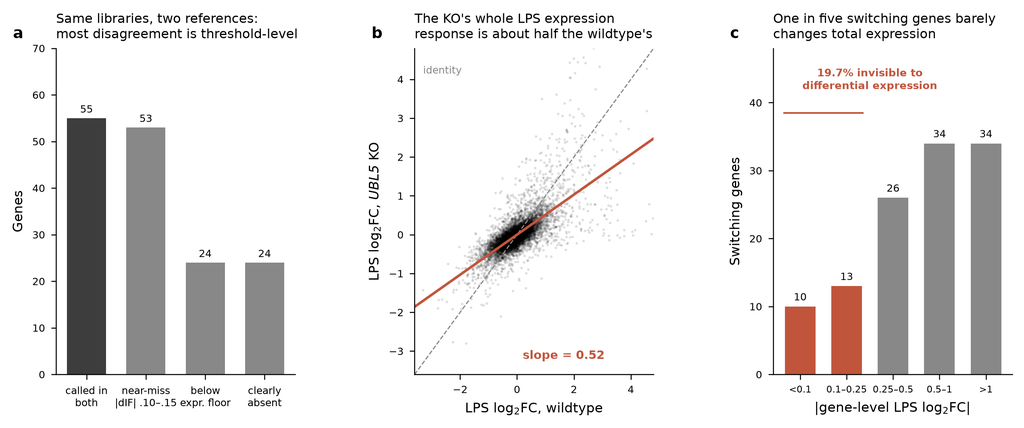

Figure 1: F1 — What the data is: same-library reproducibility (a), the KO’s halved expression response (b), and switching genes invisible to differential expression (c).

## 4.1 The result: one in five switching genes is invisible to DE

This is the cleanest positive result in the project and the direct answer to “does the splicing layer see anything gene-level expression is blind to”.

Table 3: Cryptic switchers: isoform composition shifts while total gene output barely moves

| Dataset | Genes tested | Switching | Cryptic | % of switchers cryptic |
| --- | --- | --- | --- | --- |
| T_UT | 9017 | 118 | 23 | 19.5 |
| U_UT | 9258 | 62 | 18 | 29.0 |
| T_HT | 8153 | 95 | 25 | 26.3 |
| H_HT | 6437 | 169 | 54 | 32.0 |

In `T_UT`, **23 of 118** switching genes (19.5%) have |gene log2FC| < 0.25 — median 0.136, while shifting isoform fraction by a median of 0.171.[^3] The list is biologically pointed: **IRAK3** (IRAK-M, a negative TLR regulator), **SOCS4**, **SP1**, **RAB7B** (TLR4 trafficking), **LIG1**.

Crucially, they are **not preferentially artefacts**: 64.7% are called switching again in the independent `T_HT` annotation of the same libraries, against a 59.8% baseline for all switchers.

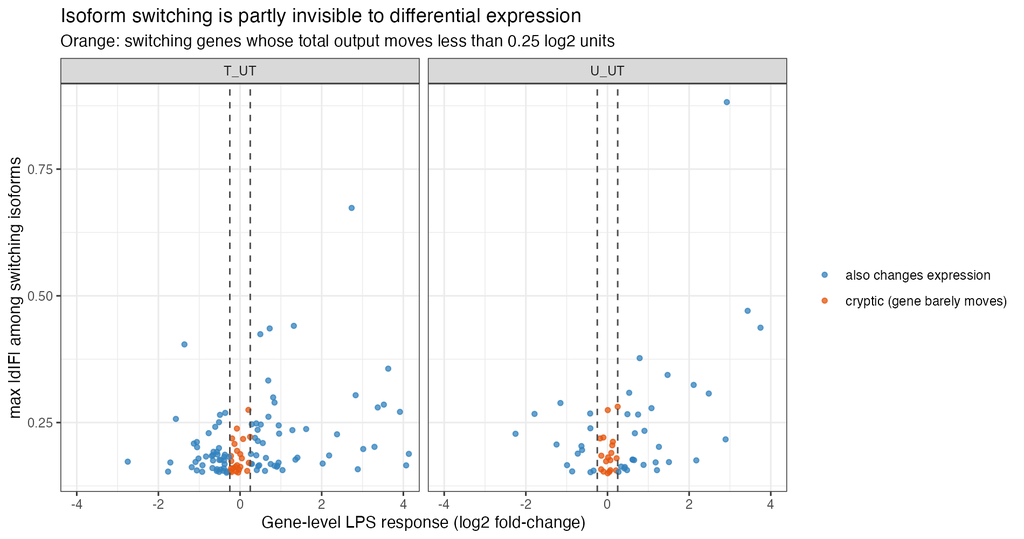

Figure 2: Cryptic switchers and the compositional-rescue class, from the pipeline’s own hidden-layer analysis (script 09).

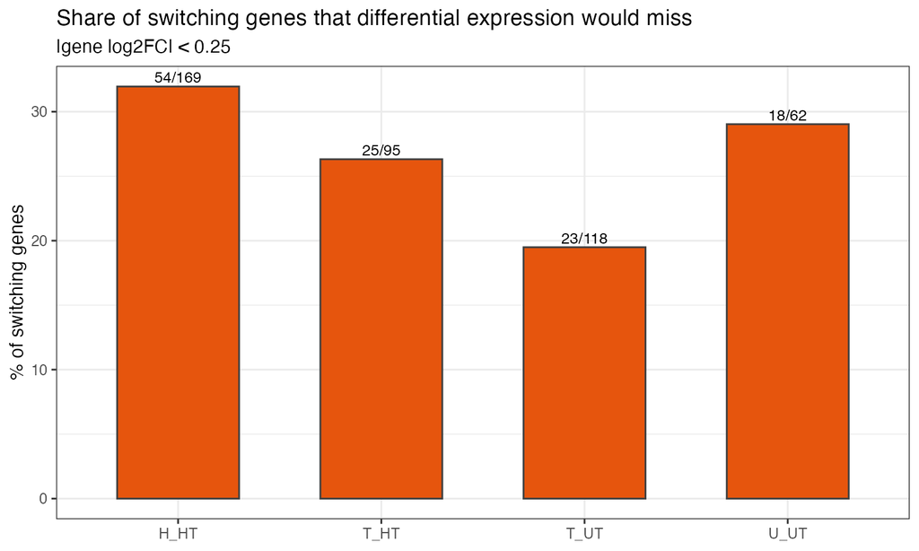

Figure 3: Cryptic switchers and the compositional-rescue class, from the pipeline’s own hidden-layer analysis (script 09).

## 4.2 Class B — “gene down, dominant isoform preserved”

A second, rarer pattern. Of 2,611 genes falling more than 0.3 log2, **56 (2.1%)** hold or raise their baseline-dominant isoform while minor isoforms collapse (median: gene −0.362, dominant −0.04, minor −0.532; dominant IF rises 0.25 → 0.32).

Dominance is defined at **baseline**, not post-LPS — defining it after stimulation selects on the outcome and inflates the class.[^4]

Reproduction, with denominators stated because they differ: of those 56, **47 are testable** in `T_HT` and **11 reproduce** as Class B there — 23.4% of the testable set, against a 0.52% base rate among all testable genes (45× enrichment, Fisher OR 78, p = 3e-16). On the conservative denominator (counting the 9 untestable as failures) it is 19.6%, a 37.5× enrichment. The reproducing genes: *AMT, CD163L1, CKAP5, COQ6, DEDD2, FBXL19, HHLA3, NRF1, RBL2, RTEL1, VPS26C*.

**NoteCorrection on the record**

An earlier draft named **IRF3** and **BCL7B** as reproducing Class B genes and used IRF3 as the illustrative example. Both have `reproduces_in_T_HT = FALSE`. IRF3 remains an interesting single-reference observation and must be labelled as not reproducing across annotations.

Structurally, Class B genes are more isoform-complex than background (median 19.5 vs 13 isoforms, Wilcoxon p = 1.6e-5) while cryptic switchers are not (p = 0.53) — mechanistically sensible, since “gene falls while the dominant isoform holds” requires enough minor isoforms to absorb the decline. **Class B looks like a property of complex loci, not a distinct functional programme**, and at 2.1% it matters for interpreting specific genes rather than as a claim that DE is broadly misleading.

## 4.3 What the switching events structurally are

This matters more than it first appears. Robinson (2021) reports that roughly half of macrophage LPS splicing changes are alternative-first-exon events — promoter choice, not spliceosome catalysis. If that held here, attributing anything to a spliceosome modifier would be undercut.

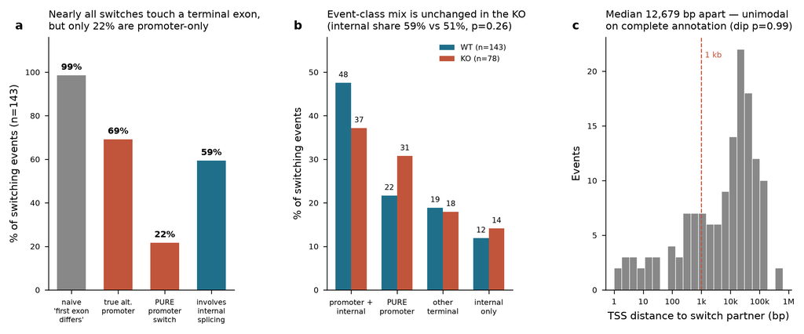

Figure 4: F4 — Event structure from the project’s own GFF3, resolving 143 of 143 WT switching events.

Table 4: Event classification, full GFF3 annotation (100% coverage)

| Criterion | % of 143 WT events |
| --- | --- |
| First exon differs (naive criterion) | 98.6 |
| True alternative promoter (disjoint, >1 kb) | 69.2 |
| **Pure** promoter switch (no internal change) | 21.7 |
| Involves internal junction change | 59.4 |
| Promoter change *plus* internal splicing | 47.6 |
| Internal splicing only | 11.9 |
| Other terminal | 18.9 |

**The answer is: partly, but not half.** 98.6% of events differ in their first exon — which is why the “it’s all first exon” impression is well founded. But under a stringent criterion (disjoint first exon *and* TSS > 1 kb apart), only **21.7% are *pure* promoter switches** with no internal junction change, while **59.4% involve a genuine internal junction change**. Robinson’s concern applies to about a fifth of events.

The event-class mix is **unchanged in the KO** (internal-splicing share 59.4% vs 51.3%, Fisher p = 0.26), so UBL5 loss does not selectively remove one event class. TSS distances are unimodal (median 12,679 bp, Hartigan dip p = 0.99).[^5]

**ImportantWording change we should adopt**

If ~22% of events are pure promoter switches and much of the rest involves 5’ truncation, a substantial fraction of what the pipeline calls “isoform switching” is **TSS selection**. That is a real and claimable regulatory layer — it is just not a spliceosome one. The reports should stop describing it generically as “splicing”.

# 5 Q2 — What UBL5 is doing

## 5.1 No constitutive splicing defect

Table 5: Baseline isoform composition, unstimulated cells only

| Contrast | Genes | Within-genotype (noise) | Between-genotype | Excess | Ratio |
| --- | --- | --- | --- | --- | --- |
| UBL5 KO vs WT (same background) | 8595 | 0.1295 | 0.1343 | 0.0024 | 1.037 |
| H vs T (different genotypes) | 5776 | 0.1087 | 0.1711 | 0.0496 | 1.574 |

Comparing **unstimulated cells only**, the KO’s excess over replicate noise is **0.0024** — essentially nil. The positive control (two genuinely different genotypes, H vs T) gives **0.0496**, about 21× larger.

So the assay detects real composition differences, and the KO at rest does not have one. **Whatever UBL5 is doing is condition-dependent.** This is a within-layer comparison with no cross-layer ratio, so it is untouched by the estimator problem below.

## 5.2 The layer asymmetry, and why it did not survive

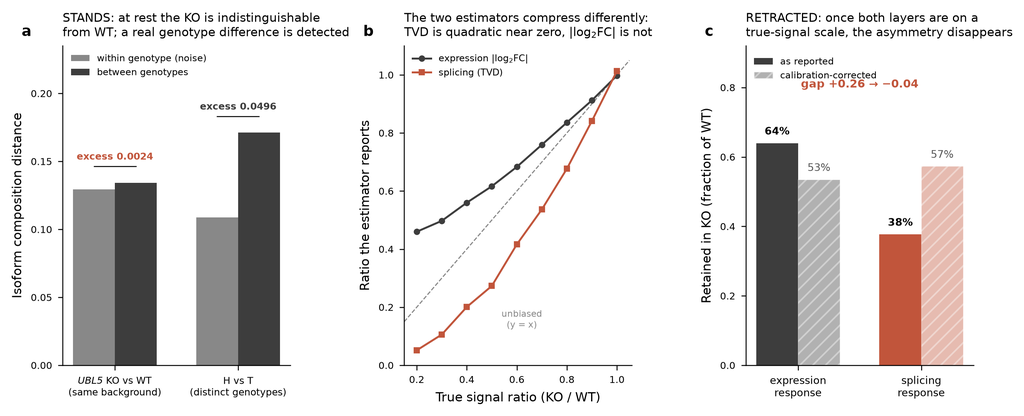

Figure 5: F2 — Q2 mechanism. Panel a stands; panels b-c document why the expression-vs-splicing asymmetry does not.

We reported that the KO retains 64% of its expression response but only 38% of its splicing response — non-overlapping CIs, robust to an annotation-neutral subset. That looked like direct evidence for a splicing-specific role.

**The two numbers come from estimators biased in opposite directions.**

- *Expression response* is |log2FC| between condition means — it averages three replicates **before** taking the absolute value, so it tracks truth almost linearly.
- *Splicing response* is a total variation distance — a **sum of absolute values**, which does not average noise away. For signal small relative to noise, $E|s+n| \approx E|n| + O(s^2)$, so the estimator is roughly **quadratic** near zero and compresses ratios toward 0.

Table 6: Simulation: what each estimator reports for a known true ratio (script 10)

| True ratio | Read by expression estimator | Read by splicing estimator (A) | Read by splicing estimator (B) |
| --- | --- | --- | --- |
| 1.0 | 0.998 | 1.013 | 0.990 |
| 0.9 | 0.912 | 0.841 | 0.869 |
| 0.8 | 0.836 | 0.677 | 0.723 |
| 0.7 | 0.759 | 0.537 | 0.590 |
| 0.6 | 0.683 | 0.416 | 0.474 |
| 0.5 | 0.616 | 0.273 | 0.340 |
| 0.4 | 0.560 | 0.201 | 0.240 |
| 0.3 | 0.497 | 0.106 | 0.135 |
| 0.2 | 0.460 | 0.052 | 0.067 |

A genotype with **60% of the true signal** reads as **68%** by the expression estimator and **42%** by the splicing estimator. Comparing an upward-biased number to a downward-biased one manufactures an asymmetry even when both layers are reduced by exactly the same factor.

Table 7: Inverting the calibration: the sign of the gap depends on the estimator

| Source | Observed expr. | Observed splicing | Corrected expr. | Corrected splicing | Observed gap | Corrected gap |
| --- | --- | --- | --- | --- | --- | --- |
| this pipeline (script 08, estimator B) | 0.603 | 0.652 | 0.476 | 0.747 | -0.049 | -0.271 |
| external review (estimator A) | 0.639 | 0.377 | 0.535 | 0.572 | 0.263 | -0.038 |

Inverting the calibration turns 64% / 38% into 53% / 57% — the observed gap of **+0.26 becomes −0.04**. The splicing layer is no longer the more-degraded one.

**ImportantThe two corrected analyses agree on direction only — do not overstate this**

The pipeline’s own estimator (observed 60% / 65%) corrects to 48% / 75%, a gap of **-0.27**, against the external review’s **-0.04**. Both corrected gaps are ≤ 0, so neither supports “splicing degrades more” — but they differ by 23 points, and the pipeline’s version implies splicing is retained ~1.6× *better* than expression, which the review’s does not.

The honest reading: after correction, **no reliable cross-layer ordering can be extracted from either estimator.** Not that both converge on parity.

Matching the estimator *structure* does not rescue the comparison. An identical across-minus-within pairwise form applied to both layers narrows the gap from 26 to 14 points (expression 53.7%, splicing 39.9%) but cannot close it, because compression depends on **signal-to-noise**, not just estimator form — and the layers differ there by **20×** (WT expression SNR 1.81, splicing 0.09). At SNR 0.09 the splicing estimator is deep in the quadratic regime while expression is not.[^6]

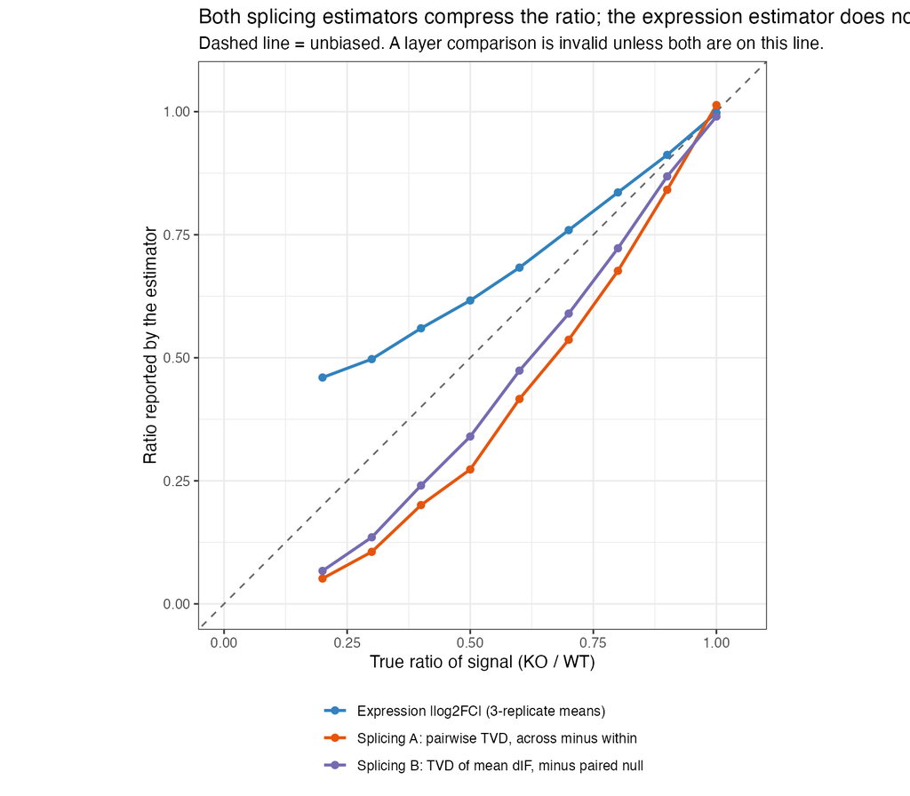

Figure 6: Estimator calibration and the corrected retention, from script 10.

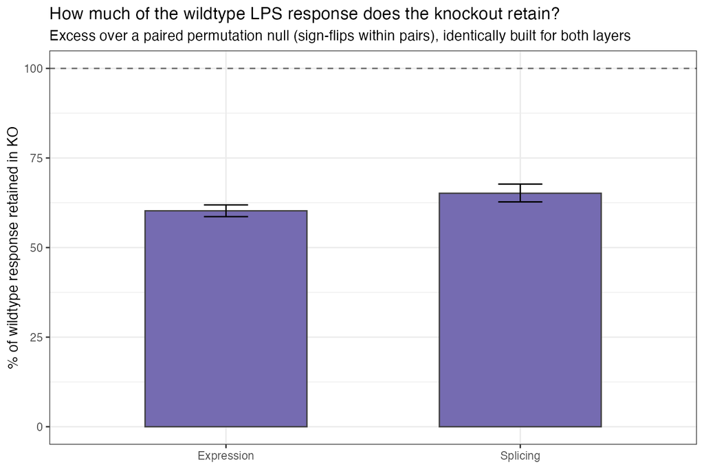

Figure 7: Estimator calibration and the corrected retention, from script 10.

**What this does and does not overturn.** It does **not** show UBL5 has no splicing-specific role — it shows *this measurement cannot demonstrate one in either direction*. It does not touch the baseline result above, and it does not touch the globally blunted expression response, which rests on expression alone.

## 5.3 The model-based refit: the interaction is nearly empty

**ImportantThis is new, and it is the test the project was blocked on**

`scripts/12_dtu_refit_2x2.R`. The RSEM matrix carries **all twelve `U-T` libraries**, so the layer question was fitted as **one `genotype x treatment` interaction** in satuRn instead of two separately-fit arms compared after the fact. That removes the cross-run normalisation problem and the estimator problem in Section 5.2 at the same time.

Table 8: satuRn, scaledTPM, BH FDR < 0.05. expected_count is fitted alongside as a sensitivity check and is uniformly more liberal (290 / 47 / 4) without changing any conclusion.

| Model | Contrast | Genes tested | Significant | % |
| --- | --- | --- | --- | --- |
| primary (~0+group) | WT_LPS | 13098 | 174 | 1.33 |
| primary (~0+group) | KO_LPS | 13129 | 37 | 0.28 |
| primary (~0+group) | interaction | 13086 | 2 | 0.02 |
| sensitivity (+rep3) | WT_LPS | 13098 | 155 | 1.18 |
| sensitivity (+rep3) | KO_LPS | 13129 | 25 | 0.19 |
| sensitivity (+rep3) | interaction | 13086 | 0 | 0.00 |

**The 174-vs-37 gap between arms does not survive being tested directly.** The interaction – “does the LPS-driven shift *differ* between genotypes?” – returns **2 genes** out of 13,086. Every earlier version of this comparison read the gap between two separately-fitted arms, which is the textbook trap of treating a **difference of significance as the significance of a difference**.

**Warning“Cannot support” is not “ruled out”**

The interaction is intrinsically the least powered contrast: it is a difference of differences, so variance adds, and its median standard error is **0.655 against 0.470** for the WT main effect. At n = 3 per group a real but modest interaction would not be detected. The Q2 verdict therefore stays **unresolved** rather than moving to rejected.

### 5.3.1 Retention, finally on one scale

Both arms now come from the same model and the same estimator, so a KO/WT ratio is like-for-like – which the retracted 64% / 38% never was.

Table 9: Slope through the origin, KO = beta x WT, on WT-significant isoforms

| Scale | Model | Isoforms (WT-sig) | Retention (lower bound) | 95% CI |
| --- | --- | --- | --- | --- |
| scaledTPM | primary (~0+group) | 238 | 0.557 | 0.487-0.627 |
| scaledTPM | sensitivity (+rep3) | 205 | 0.551 | 0.464-0.638 |
| expected_count | primary (~0+group) | 397 | 0.471 | 0.42-0.521 |
| expected_count | sensitivity (+rep3) | 373 | 0.414 | 0.352-0.476 |

Retention is **at least 56%** – consistent with the old *expression* figure (~64%) and **not** with the retracted *splicing* figure (38%). On a single estimator the two layers degrade at similar rates, which is exactly what Section 5.2 predicted once the calibration was inverted.

It is a **lower bound** because selecting isoforms on WT significance gives the WT estimates a winner’s curse, inflating the denominator and biasing the slope down; the KO estimates for those isoforms are unselected and stay unbiased.[^7]

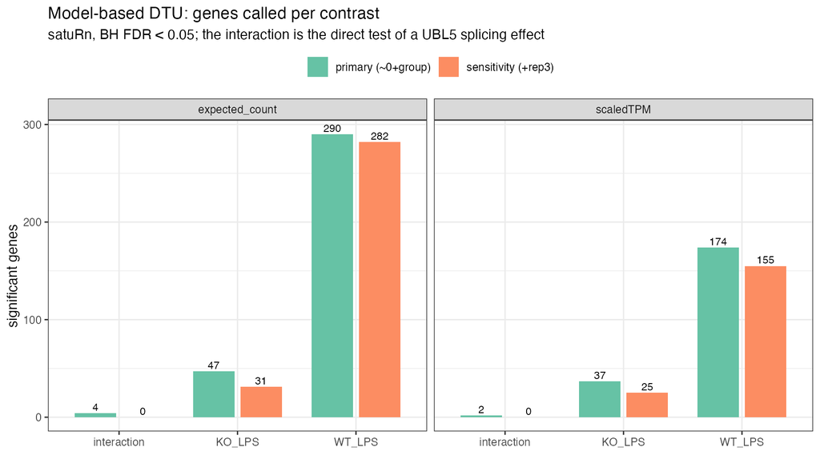

Figure 8: Genes called per contrast. The interaction – the direct test of a UBL5 splicing effect – is nearly empty in every model and on both count scales.

**NoteTwo method findings worth carrying**

**satuRn’s empirical FDR fails at n = 3.** Its `locfdr`-based null misfits on every contrast and never drops below q ~ 0.30 – it returns **zero** genes even for the WT LPS effect, which ISA independently calls for 118 genes. A correction that finds nothing where the positive control is strongest is broken, not conservative. BH is reported; both are written to `dtu_refit_fdr_comparison.csv`.

**The paired design cannot be blocked here.** A 6-level pair factor is rank deficient in the 2x2 (ncol 9, rank 8) because pair nests entirely inside genotype. The primary model is unblocked; a `+ rep3` sensitivity fit assumes T1 and U1 were matched batches, which is unconfirmed. They agree throughout.

**Count scale, settled and recorded:** **scaledTPM** primary, since raw expected counts are biased by effective-length differences between isoforms of the *same* gene – precisely the comparison DTU makes. This closes the open decision from the last update.

## 5.4 What the deficit is *not*

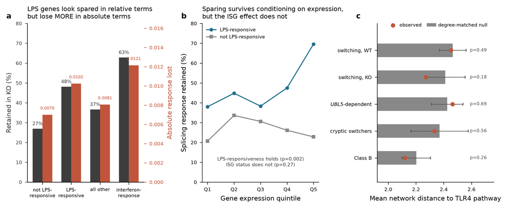

Figure 9: F3 — Three negative controls: the sparing artefact (a), conditioning on expression (b), and network proximity against a degree-matched null (c).

**Not LPS-pathway-specific.** If UBL5 were required for an LPS-induced splicing programme, the deficit should concentrate in LPS-responsive genes. It does the opposite on the relative scale — and that reading is the artefact:

Table 10: The same table read two ways: relative retention suggests sparing, absolute loss says the opposite

| Class | n | WT | KO | % retained (relative) | Absolute loss |
| --- | --- | --- | --- | --- | --- |
| LPS-responsive | 2892 | 0.01973 | 0.00949 | 48.1 | 0.01024 |
| Not LPS-responsive | 5703 | 0.00958 | 0.00258 | 26.9 | 0.00700 |
| All other | 8404 | 0.01271 | 0.00465 | 36.6 | 0.00806 |
| Interferon-response | 131 | 0.03265 | 0.02050 | 62.8 | 0.01215 |

Interferon-response genes retain 62.8% against a 36.6% transcriptome average — but they *lose* 0.0122 in absolute terms against 0.0081. Conditioning on expression quintiles, LPS-responsiveness stays significant (p = 0.002) while **ISG status does not (p = 0.27)**. The interferon effect was abundance. Report both scales or neither.

**No network proximity to TLR4.** Using the full STRING v12 human physical interactome (15,809 proteins, 210,667 edges at score ≥ 400) seeded with 33 TLR4-pathway proteins and tested against a **degree-matched null**, every candidate set is non-significant: switching in WT p = 0.49, KO p = 0.18, UBL5-dependent p = 0.69, cryptic p = 0.56, Class B p = 0.26.

The reason is structural and visible in the null itself — degree-matched *random* genes sit only 2.20–2.47 steps from the pathway (SD 0.10–0.24). In a network this dense, almost every expressed gene is two to three steps from TLR4, so **distance carries almost no discriminating information**.[^8]

## 5.5 What survives on the positive side

Two results from the network work do stand:

- A short list of candidates that are **genuine direct physical interactors** of pathway components (`direct_TLR4_interactors.csv`).
- **UBL5’s own neighbourhood: 62% of its 82 partners are core spliceosome or RBP**, including a direct **SART1** edge — the mammalian counterpart of the known Hub1–Snu66 interaction. Its single apparent TLR4 link is to UBE2N and is best read as ubiquitin-system co-annotation, not signalling.

This is suggestive of a spliceosomal role, but it is **annotation, not measurement** from our data. It cannot substitute for the refit.

# 6 Candidates for validation

## 6.1 Q1 candidates — two lists, two questions

The candidate set carried through the external review (IRAK3, SOCS4, RAB7B, SPRING1) is **Q2-shaped**. Its chain is: 117 switching genes in `T_UT` → 23 cryptic → **4 genes hand-picked for TLR-pathway relevance** → 7 isoforms. Their ranks among the 23 cryptic switchers are 1, 3, **10** and **11**, so this is a judgement call for assay design, not a statistical selection — no claim of the form “the top candidates are TLR genes” follows from it.

Two gaps followed, and `scripts/11_q1_candidates.R` now fills them. The set never used **`T_HT`, the designated Q1 anchor**; and the cryptic filter, while exactly right for the sub-question, discards the largest switches in the data purely because those genes also change in abundance.

**NoteWhy these are two lists rather than one ranked table with a flag**

“Invisible to DE” is a **sub-question within Q1, not the main one**, so it gets its own list. A gene can be a strong answer to one and irrelevant to the other. Ranking the response list by effect and then filtering it to cryptic would bury the point of the cryptic list, where **membership is the finding** and rank is secondary.

Table 11: Q1 candidate accounting across the two wildtype annotations of the same six libraries

| Metric | n |
| --- | --- |
| genes switching in the anchor (T_HT) | 95 |
| genes switching in the re-annotation (T_UT) | 117 |
| union across the two wildtype annotations | 157 |
| annotation-robust (switching in both) | 55 |
| never testable in one annotation | 25 |
| tested in both, called in one | 77 |
| LIST A – response candidates (robust, ranked) | 20 |
| LIST B – cryptic candidates (invisible to DE) | 37 |
| of those, annotation-robust | 8 |
| of those, also switching in H_HT | 2 |

### 6.1.1 List A — the wildtype LPS response

The main Q1 question, ranked purely by effect size.

Table 12: Top 12 of 20 annotation-robust wildtype LPS switchers. Full list in q1_response_candidates.csv

| Rank | Gene | max \|dIF\| | gene log2FC | Class | Cross-genotype (H_HT) |
| --- | --- | --- | --- | --- | --- |
| 1 | NCOA7 | 0.652 | 2.86 | =,c | also switches in H_HT |
| 2 | RBKS | 0.465 | 1.26 | = | tested in H_HT, not switching |
| 3 | THAP2 | 0.439 | 0.36 | = | not testable in H_HT |
| 4 | RSAD2 | 0.367 | 4.24 | =,c | also switches in H_HT |
| 5 | CD86 | 0.344 | 0.09 | = | tested in H_HT, not switching |
| 6 | MREG | 0.318 | 0.53 | = | not testable in H_HT |
| 7 | KDM6B | 0.304 | 2.73 | = | tested in H_HT, not switching |
| 8 | KITLG | 0.294 | 0.72 | = | tested in H_HT, not switching |
| 9 | IPCEF1 | 0.290 | 0.14 | =,c | tested in H_HT, not switching |
| 10 | IFITM2 | 0.289 | 0.77 | = | also switches in H_HT |
| 11 | DDX58 | 0.282 | 3.42 | =,c | tested in H_HT, not switching |
| 12 | IL23A | 0.266 | 4.43 | = | tested in H_HT, not switching |

A coherent interferon and inflammatory signature — **NCOA7, RSAD2, DDX58, IFITM2, IL23A, CCL3, CD86, KDM6B, GBP1** — and almost entirely disjoint from the Q2 four.

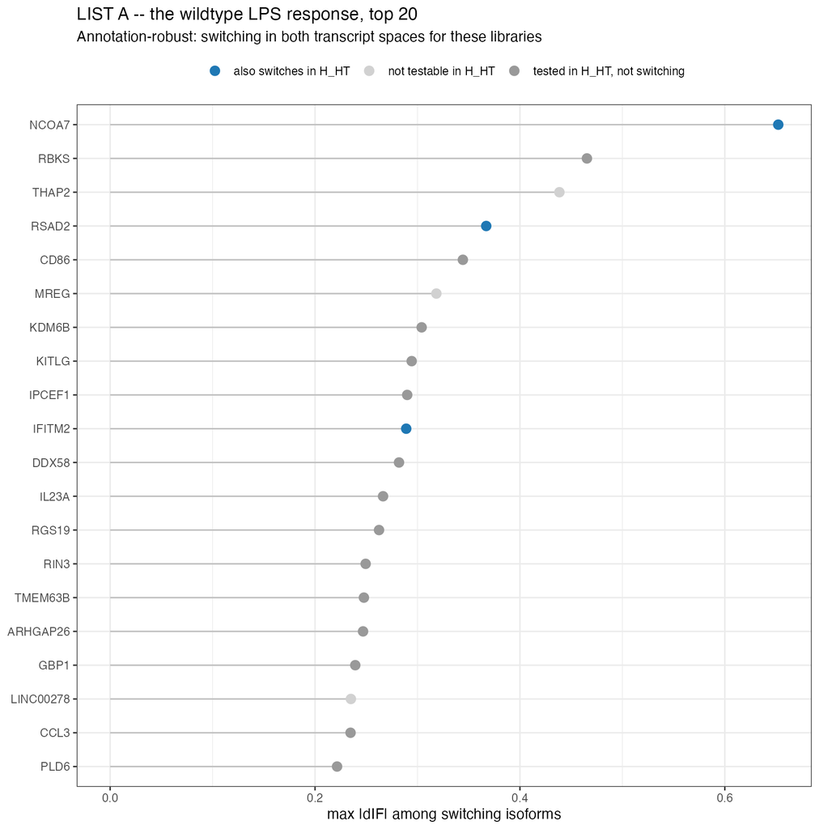

Figure 10: List A — the wildtype LPS response, ranked by effect among annotation-robust switchers.

### 6.1.2 List B — switches differential expression would miss

The sub-question, and the one the hidden-layer analysis is about. 37 genes qualify; **8** are annotation-robust.

Table 13: Cryptic candidates, annotation-robust first. Full list in q1_cryptic_candidates.csv

| Rank | Gene | max \|dIF\| | gene log2FC | Class | Annotation status |
| --- | --- | --- | --- | --- | --- |
| 1 | CD86 | 0.344 | 0.091 | = | robust (called in both) |
| 2 | IPCEF1 | 0.290 | 0.141 | =,c | robust (called in both) |
| 3 | PLD6 | 0.222 | 0.169 | = | robust (called in both) |
| 4 | CTTNBP2NL | 0.221 | -0.118 | = | robust (called in both) |
| 5 | ATRN | 0.208 | -0.200 | = | robust (called in both) |
| 6 | ACP3 | 0.173 | -0.152 | = | robust (called in both) |
| 7 | PCSK7 | 0.165 | -0.101 | c | robust (called in both) |
| 8 | SOCS4 | 0.162 | 0.015 | = | robust (called in both) |
| 9 | TMEM234 | 0.268 | -0.147 | = | tested in both, called in one |
| 10 | ALKBH3 | 0.267 | -0.136 | = | tested in both, called in one |
| 11 | PHLDA3 | 0.251 | -0.197 | = | tested in both, called in one |
| 12 | IRAK3 | 0.238 | -0.077 | = | not testable in T_HT |

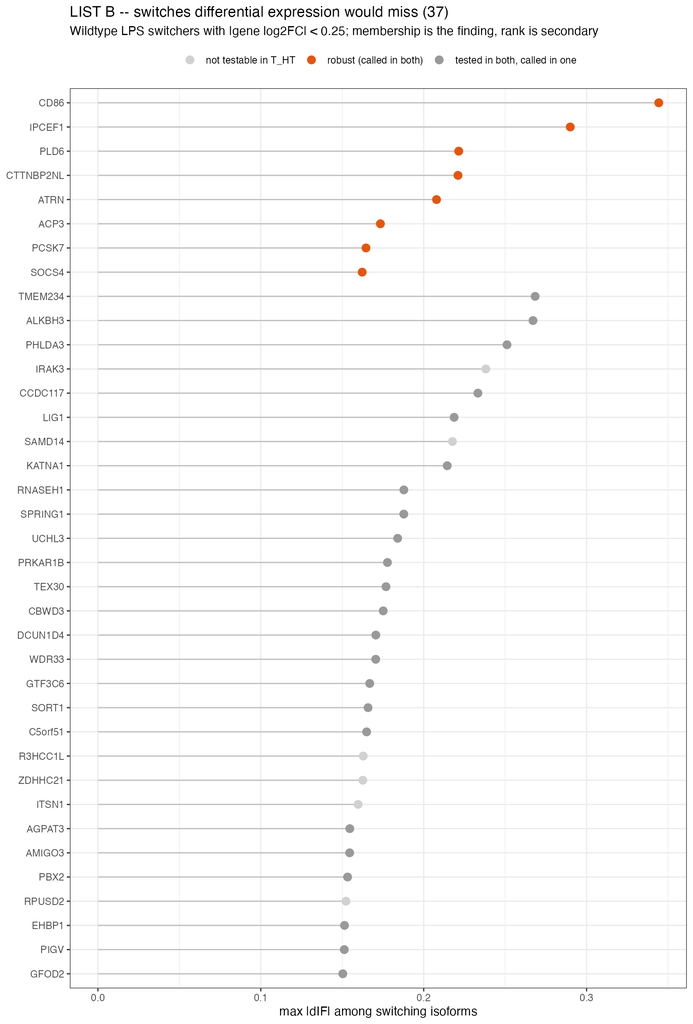

Figure 11: List B — cryptic candidates. Membership is the finding; rank is secondary.

**WarningRead the `Class` column: `c` means the call rests on a contained transcript**

`class_codes` is the gffcompare code of the gene’s **switching** isoforms — `=` matches a reference transcript end to end, `c` is **contained** inside one, `j` is a novel junction combination.

**`c` is the one to read carefully.** Structurally it means the isoform starts inside another and shares all of its junctions — our nested candidates begin a median of **25 kb** downstream of their host and contribute no new splice site, which is **promoter choice, not a spliceosome event**. That is a real and documented mechanism. But `c` is *equally* the code a **5′-incomplete assembly** lands in: a PacBio read that never reached the 5′ end, or degraded input. Without cap selection those are produced in quantity, and this data cannot separate the two.[^9]

- **List A:** 4 of 20 genes have a `c`-class switching isoform (NCOA7, RSAD2, IPCEF1, DDX58) — each also has an `=`-class one, so no call rests on contained transcripts alone.
- **List B:** 7 of 37, and **6 rest entirely on `c`** — PCSK7, CCDC117, SPRING1, DCUN1D4, SORT1, ITSN1. These are the exposed ones. SPRING1 landing here is coherent: it is the review’s Q2 candidate that failed to reproduce in `T_HT`.
- **RBKS**, the strongest assay candidate, is pure `=` on both sides of its switch.

Resolving this needs one fact we do not have — see Section 8.

**WarningTwo things this table is careful about**

**Failing annotation-robustness has two different causes.** A gene *tested* in the other annotation and not called is a real disagreement; a gene below the **expression floor** there was never given the chance. **IRAK3** is the worked example — gene expression 10.3 in `T_HT` against a floor of 12 — so its absence from the anchor is missing data, not evidence against it. The `annotation_status` column keeps these apart.

**`T_HT`/`T_UT` agreement is robustness to transcript space, not replication.** Same six libraries, same RNA. `H_HT` agreement *is* genuine cross-genotype support, but it is reported as a flag only and never used as a filter, since `H_HT` alone is batch-corrected (Section 3.1). No `H_HT` effect size is compared to a `T` effect size anywhere.

## 6.2 Can the Q1 candidates actually be measured?

`scripts/13_assayability_screen.R` applies the same screen that eliminated 6 of the 7 Q2 candidates: an isoform is undesignable if it is **nested** inside a longer isoform of the same gene (every base and every junction contained, so no primer pair can discriminate it), or if the other isoforms **tile over** it leaving no unique run of at least 60 bp.

**NoteThe screen was validated before it was trusted**

Run against the review’s 7 Q2 isoforms it reproduces all five checkable verdicts exactly, including the subtle SOCS4 case — `TCONS_00086549` is *not* nested but has only **6 bp** of unique sequence, so it fails for a different reason than the other four.

Table 14: Assayability of the Q1 candidate isoforms and the genes they belong to

| Metric | n |
| --- | --- |
| candidate isoforms screened | 63 |
| designable | 25 |
| nested (undiscriminable) | 13 |
| tiled over (<min unique bp) | 25 |
| absent from GFF3 | 0 |
| candidate genes | 40 |
| both sides designable | 5 |
| one side designable | 15 |
| no designable isoform | 20 |

**25 of 63 isoforms are designable** — materially better than Q2’s 1 of 7. More useful still, **5 genes have *both* the falling and the rising isoform designable**, which the Q2 set had none of. That matters because it lets the switch be measured *as a switch* rather than inferred from one side.

Table 15: Genes with at least one designable isoform, best first

| Gene | List | Designable isoforms | Nested | Longest unique (bp) | Verdict |
| --- | --- | --- | --- | --- | --- |
| ATRN | cryptic | 2 | 0 | 4396 | both sides designable |
| PLD6 | cryptic+response | 2 | 0 | 1654 | both sides designable |
| RBKS | response | 2 | 0 | 273 | both sides designable |
| KDM6B | response | 2 | 0 | 147 | both sides designable |
| SAMD14 | cryptic | 2 | 0 | 104 | both sides designable |
| WDR33 | cryptic | 1 | 0 | 5526 | one side designable |
| ZDHHC21 | cryptic | 1 | 0 | 4464 | one side designable |
| IRAK3 | cryptic | 1 | 1 | 3465 | one side designable |
| ACP3 | cryptic | 1 | 0 | 2670 | one side designable |
| AGPAT3 | cryptic | 1 | 0 | 1056 | one side designable |
| MREG | response | 1 | 1 | 803 | one side designable |
| THAP2 | response | 1 | 0 | 572 | one side designable |

**RBKS is the strongest single candidate**: both sides of the switch (dIF −0.33 and +0.44) with 110 and 273 bp of unique sequence. KDM6B, ATRN, PLD6 and SAMD14 also have both sides.

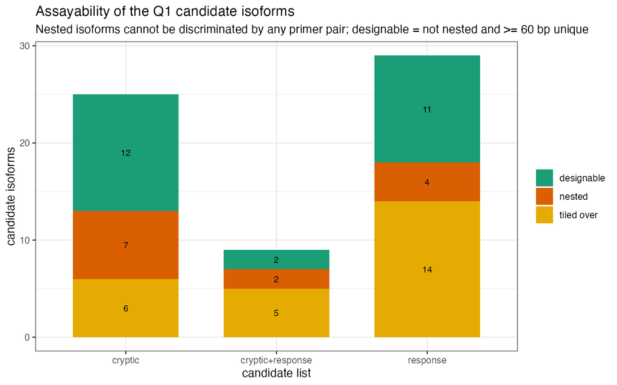

Figure 12: Why candidates fail. Nested isoforms cannot be discriminated by any primer pair; tiled-over ones have no room to design into.

The improvement over Q2 tracks Section 4.3: the response list carries large **internal splicing** switches, not only the promoter switches that make an isoform nested by construction.

**WarningWhat this screen does not do**

It does not design primers or run the empirical specificity match against all 315,349 transcripts — the step that confirmed the one surviving Q2 assay at 1-of-315,349. That is the next task and only makes sense for the 25 survivors, which are written out with their unique interval so design can start from a coordinate.

## 6.3 Q2 candidates and assay feasibility

Table 16: Lead candidates and their cross-annotation status

| Gene | Cryptic rank | Expr WT | log2FC WT | max \|dIF\| WT | Testable in T_HT | Reproduces |
| --- | --- | --- | --- | --- | --- | --- |
| IRAK3 | 3 | 14.1 | -0.109 | 0.238 | False | False |
| SOCS4 | 10 | 23.0 | 0.049 | 0.180 | True | True |
| RAB7B | 11 | 714.6 | -0.217 | 0.174 | True | True |
| SPRING1 | 1 | 32.1 | 0.012 | 0.284 | True | False |

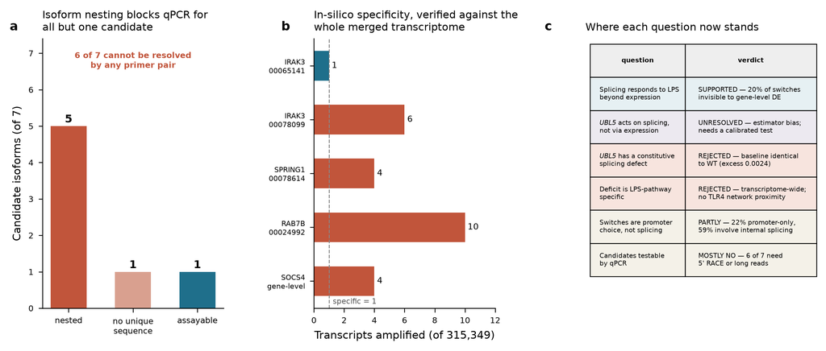

Figure 13: F5 — Assay feasibility and the verdict per question.

**WarningMost of these cannot be assayed by qPCR, for a structural reason**

Of 7 candidate isoforms, **5 are fully nested** inside a longer isoform — every junction and every base they contain is also present in the host transcript, so **no primer pair can distinguish them**. A 6th (SOCS4 `TCONS_00086549`) is not nested but still has zero unique sequence ≥ 60 bp, because other isoforms tile across all of it.

That leaves **one** designable assay: the **IRAK3** long form `TCONS_00065141` — 129 bp product, specificity verified empirically as **1 of 315,349 transcripts** by matching both primers against every transcript in `fa/transcripts_U-T.fa`, not predicted.

**The right assays instead:** the discriminating feature for the nested isoforms is the 5’ end (TSS 863 bp to 55.8 kb apart), so **5’ RACE, CAGE, or targeted long-read cDNA**. Long-read cDNA on the validation RNA would resolve all seven at once and is likely cheaper than developing six assays that cannot work.

# 7 Methods notes worth carrying forward

Short version of the traps this project has actually fallen into. Full treatment in `docs/STATISTICAL_METHODS.md`.

**Backgrounds.** Every enrichment test uses the genes *quantified and tested in that same experiment* (8,000–12,000 per dataset), recovered from unfiltered exports. Never the whole genome, and never the saved analysis objects — those were written with `reduceToSwitchingGenes = TRUE`, so every gene in them is already significant. One early test in this project had a background of **25 genes, all significant by construction**, and reported an odds ratio of 15.

**The abundance floor.** `min_gene_expression = 12`, derived from replicate IF noise versus gene expression. dIF is a ratio, so at low *gene* abundance the isoform fraction rests on few reads. It removes 33–52% of raw calls by design, and `is_switching_before_expr_floor` is kept so the cost stays auditable.[^10]

**Effect sizes over p-values.** With thousands of matched isoforms, p-values track n. A paired Wilcoxon p of 7e-9 on a median log2 ratio of 0.003 is sample size, not biology.

**Calibrate before comparing layers.** The general lesson from Section 5.2: *any* claim of the form “layer X is affected more than layer Y” needs its estimators calibrated first. The results in Section 4 and Section 5.4 do not have this problem — they are within-layer comparisons, proportions, or structural classifications.

**The measurement ceiling on all of this.** Everything above derives from ISA’s condition means and replicate isoform fractions. The composition measure is a reasonable summary but is **not a formal differential-splicing test**, and Section 5.2 is the concrete cost of that.

# 8 Where we need your input

These are blocking or near-blocking, and we cannot resolve them from the data.

**1. What exactly is the UBL5 allele?** Full knockout, frameshift, hypomorph, degron, or knockdown? Published work reports human UBL5 as **essential for viability** (Ammon et al. 2014), so a viable complete null needs explaining. If it is a hypomorph or partial knockdown that changes the interpretation substantially and reconciles a literature contradiction. This is the cheapest thing on the list and its outcome reframes everything else.

**2. Library chemistry — polyA-selected or ribo-depleted?** **Intron retention** is the readout most diagnostic for a Hub1/UBL5 mechanism, and it is poorly captured by polyA selection. If the existing libraries are polyA, the central falsification test needs new sequencing.

**3. Was the PacBio/IsoSeq library cap-selected?** (TeloPrime, or IsoSeq with 5′-cap verification.) This is new since the last update and it is not just a QC detail. **23,044 of the 166,394 quantified transcripts in the UT reference — 13.8% — are class `c`** — contained inside another isoform. Those are either genuine alternative-internal-promoter isoforms or 5′-incomplete assemblies, and without cap selection the second class is produced in quantity. It decides how much of the `c`-class transcript space to trust, which in turn affects 7 of the 37 cryptic candidates — 6 of which rest on `c`-class transcripts *alone* (Section 6.1).

**4. LPS dose, timepoint, and PMA differentiation protocol.** Needed so any validation experiment matches the original conditions.

**5. SETTLED — the count scale is now recorded, no decision needed.** The refit uses **scaledTPM** as primary, since raw expected counts are biased by effective-length differences between isoforms of the same gene, with `expected_count` fitted alongside every run as a standing sensitivity check. Flag it if you disagree; otherwise this one is closed.

**6. Is the TSS reframing acceptable?** Given Section 4.3, should we retitle this work from “isoform switching” to something that leads with promoter/TSS selection? It is more accurate and arguably a *cleaner* story, but it changes the framing of the whole project.

# 9 What’s planned next

Ordered by what would change a conclusion.

**1. DONE — the model-based refit is complete (Section 5.3).** It was the blocking step and it is no longer blocking; what remains is what it could not settle, below. Original framing kept for context: RSEM matrices for **all twelve libraries per reference** arrived and every ISA object has been reconciled against them. Because the UT file carries all twelve, the layer question becomes a `genotype × treatment` **interaction in one 2×2 model** rather than a comparison of two separately-fit runs — which removes the cross-run normalisation problem *and* the estimator problem in Section 5.2 at the same time.

Plan: `satuRn` or `DEXSeq`, with the pairing included and an **explicit blocking factor** (`~ donor + condition` for H, `~ replicate + condition` for T/U), re-imported under a single ISA version.[^11] The claim stays unresolved after it, but for a different reason: the interaction is underpowered at n = 3, not un-tested. **Resolving it needs more replicates or a larger perturbation, not another estimator.**

**2. Design and specificity-check primers for the 25 survivors.** The screen (Section 6.2) says *where* a discriminating primer can sit; it has not designed one or matched it against all 315,349 transcripts. Start with the five both-sides genes — RBKS first.

**3. Recompute the mediation decomposition on a calibrated scale.** It inherits the compressed estimator and is currently unquotable.

**4. Promote the hidden-layer analysis into the pipeline.** `scripts/03b_hidden_layer.R` writing per-dataset cryptic-switcher and Class B tables with cross-annotation reproduction flags, so these stop living only in the review tree.

**5. GO enrichment on the hidden-layer sets.** Could not be run during the review — Bioconductor mirrors were unreachable from that sandbox. `gene_sets/` has everything needed (`universe_tested_genes.txt`, 8,916 symbols, plus the four candidate sets); feed them through `05_pathway_enrichment.R` so the universe convention matches the rest of the project. At 11–56 genes this is likely underpowered, so a more informative alternative is to annotate the **isoforms** instead — are the lost minor isoforms NMD targets or truncated, and the retained dominant ones full-length coding? That converts “purification” from a pattern into a mechanism.

**6. Re-examine the abundance floor under a paired noise model.** The floor was derived from within-condition replicate IF noise without using the pairing; a paired estimate should be smaller and would recover some of the 33–52% of calls currently removed. Do this **after** the re-import, not before.

**7. Wet-lab sequence** (full proposal, ordered cheapest-potentially-fatal-first, in `docs/external_review/EXPERIMENTS.md`): allele characterisation → intron retention under stimulation, ribo-depleted → the IRAK3 assay → independent perturbation as a clonal-artefact control → rescue, only once the first three support the model.

# 10 Appendix — provenance

Table 17: Which table backs which claim (`xr:` = docs/external_review/tables/)

| Claim | Backing table |
| --- | --- |
| Cryptic switchers | results/tables/hidden_layer_*.csv; xr: cryptic_switchers_T_UT.csv |
| Class B reproduction | xr: class_b_purification_T_UT.csv |
| Event structure | xr: event_structure_{summary,WT,KO}_gff3.csv |
| Baseline composition | xr: baseline_composition_test.csv |
| Estimator calibration | results/tables/layer_estimator_calibration.csv |
| Corrected retention | results/tables/layer_retention_corrected.csv |
| Sparing, both scales | xr: sparing_relative_vs_absolute.csv |
| Network distance | xr: network_distance_to_TLR4.csv |
| Primer designs | xr: primer_designs.csv |
| H_HT batch correction | docs/REVIEW_CHANGES.md §0g |

Every table in `results/` carries a `run_manifest.json` entry recording the git SHA, R version, package versions and thresholds that produced it. Reports are read-only consumers of those tables.

**Standing caveats.** The four ISA objects are pre-reduced to switching genes, so “genes present” ≠ “genes tested”; significance always comes from the unfiltered context layer, never from the reduced objects. `TCONS_*` ids are assigned per reference and are not comparable across HT and UT — cross-reference comparisons join on gene symbols.

**ImportantInputs are already reduced to switching genes**

All 4 of 4 input ISA objects contain **only genes that already pass the gene-level q cutoff** (saved after `isoformSwitchTestDEXSeq(reduceToSwitchingGenes = TRUE)`).

Consequences for everything below: gene counts are *genes retained*, not *genes tested*; “present in the other dataset” means *retained in that saved object*, not *tested and non-significant*; and any percentage of genes has a denominator that was already selected on the outcome. Overlap between datasets is bounded by how many symbols survive in both objects. No enrichment test against this background is reported. See `docs/REVIEW_CHANGES.md`.

## Footnotes

[^1]: Both causal orderings — “blunted response reduces switching” and “impaired splicing blunts the response” — predict exactly this correlation. With two conditions and n = 3 there is no design-based way to separate them. `docs/STATISTICAL_METHODS.md` §2.6.
[^2]: Verified by reconciling all four objects against the raw RSEM counts. `T_HT`, `T_UT` and `U_UT` reproduce exactly (dIF r = 1.0000, residual at the four-decimal rounding of the stored IFs). `H_HT` reproduces only once the correction is reapplied (r = 0.777 → 0.99915). `docs/REVIEW_CHANGES.md` §0g.
[^3]: The threshold is deliberately strict. These are not genes with a *modest* expression change; they are genes where total output is essentially flat and the composition moves underneath it.
[^4]: This is the tempting bug in this analysis and is asserted in a comment in the script for that reason.
[^5]: An apparent bimodality on the earlier Ensembl-only subset (dip p = 0.008) did not survive complete annotation and is retracted. It came from coordinate disagreement between the two annotations (Spearman 0.649), not biology. This is also why the earlier AFE percentages changed so much: the Ensembl pass resolved only 68 of 143 events.
[^6]: The simulation assumes Gaussian homoscedastic noise, so the *magnitude* of the correction is approximate. The *direction* of the two biases is not — it follows from the algebra of averaging before versus after an absolute value.
[^7]: The unselected transcriptome-wide slope (0.068) is **not** a retention estimate and is kept only as a diagnostic. The reliability of the WT estimate – the share of its observed variance that is signal rather than measurement error – is **0.0066**, so ~99% of that spread is noise and the slope measures regression dilution. The standard correction (divide by reliability) is unstable there and returns beta > 10. Any future transcriptome-wide ratio must report its reliability alongside it.
[^8]: This is worth remembering before we run any similar proximity analysis: without a degree-matched null, hub genes make everything look close to everything.
[^9]: Mild reassurance: the nested forms do not move as a class — 8 rise, 5 fall (p = 0.58), against 22/28 for the non-nested candidates. A uniform 5′-coverage shift would push them all one way. Not conclusive, since a technical effect could be gene-specific.
[^10]: The floor is on **gene** expression, not isoform expression — IF is isoform/gene, so it is gene abundance that sets the precision. Note that `H_HT`’s recommended floor (6.02) is the lowest of the four *because* its noise was halved by the batch correction; `02d` takes the median of the four, so the effect on the applied value is modest (~11 vs ~12.5), not a distortion.
[^11]: `satuRn` 1.12.0, `DEXSeq` 1.50.0, `edgeR` and `limma` are installed; `DRIMSeq` is **not**. Counts are fractional (RSEM EM output) — fine for satuRn, round for DEXSeq. Requires the external drive to be mounted.